# Analysis logbook - experiment 2

Alexandre Nobre

2024-05-10

Este documento detalha as estratégias de seleção de modelos para as análises com modelos mistos.

# 0. Funções

Inicialmente criamos as funções utilizadas para comparar os modelos: uma função para construir histogramas bonitos e uma função para construir tabelas com estatísticas de ajuste.

```r
hist_resid <- function(M,ptitle='Residuals') {
  d <- data.frame(resid=residuals(M))
  d  %>% ggplot(aes(x=resid)) +
    geom_histogram(aes(y=after_stat(density)), bins=75, color='black', fill='grey') +
    geom_density(color='darkred') +
    ggtitle(ptitle) -> pl
  return(pl)
}

fitstats = function(M,mname='M') {
  QQ<-qqnorm(residuals(M), plot.it=FALSE)
  R2qq <- cor(QQ$x,QQ$y)^2
  dfqq = data.frame(stat='R2qq', V1=R2qq)
  r2tab <- r.squaredGLMM(M)  %>%
    t  %>% as.data.frame  %>% rownames_to_column(var='stat')  %>%
    rbind(.,dfqq)
  r2tab$stat = c("$R^2_m$","$R^2_c$",'$R^2_{qq}$' )
  colnames(r2tab) <- c('stat',mname)
  return(r2tab)
}
```

# 1. Seleção das variáveis dependentes

Para estes modelos, inicialmente fazemos a seleção das variáveis dependentes. A seleção é feita comparando-se os ajustes de modelos mistos com cada variável dependente, incluindo como apenas o intercepto como modelo aleatório. Os valores de ajuste utilizados são:

- Variância explicada pelos efeitos fixos
- Variância explicada pelo modelo completo
- Normalidade dos resíduos
- Correlação entre valores ajustados pelo modelo e dados

As variáveis comparadas são:

- RT bruto
- 1/RT
- log10(RT)

```r
# Fit models with RT, inverse RT, and logRT without trimming
fplmm1 <- mixed(formula = RT ~ foreperiod*condition*oneBackFP +
                  (1|ID),
                data = data,
                control = lmerControl(optimizer = c("bobyqa"),optCtrl=list(maxfun=2e5),calc.derivs = FALSE),
                progress = TRUE,
                expand_re = TRUE,
                method =  'S',
                REML=TRUE,
                return = "merMod")

invfplmm1 <- mixed(formula = invRT ~ foreperiod*condition*oneBackFP +
                     (1|ID),
                   data = data,
                   control = lmerControl(optimizer = c("bobyqa"),optCtrl=list(maxfun=2e5),calc.derivs = FALSE),
                   progress = TRUE,
                   expand_re = TRUE,
                   method =  'S',
                   REML=TRUE,
                   return = "merMod")

logfplmm1 <- mixed(formula = logRT ~ foreperiod*condition*oneBackFP +
                     (1|ID),
                   data = data,
                   control = lmerControl(optimizer = c("bobyqa"),optCtrl=list(maxfun=2e5),calc.derivs = FALSE),
                   progress = TRUE,
                   expand_re = TRUE,
                   method =  'S',
                   REML=TRUE,
                   return = "merMod")

# Now fit models after outlier trimming
trimfplmm1 <- mixed(formula = RT ~ foreperiod*condition*oneBackFP +
                      (1|ID),
                    data = data2,
                    control = lmerControl(optimizer = c("bobyqa"),optCtrl=list(maxfun=2e5),calc.derivs = FALSE),
                    progress = TRUE,
                    expand_re = TRUE,
                    method =  'S',
                    REML=TRUE,
                    return = "merMod")

triminvfplmm1 <- mixed(formula = invRT ~ foreperiod*condition*oneBackFP +
                         (1|ID),
                       data = data2,
                       control = lmerControl(optimizer = c("bobyqa"),optCtrl=list(maxfun=2e5),calc.derivs = FALSE),
                       progress = TRUE,
                       expand_re = TRUE,
                       method =  'S',
                       REML=TRUE,
                       return = "merMod")

trimlogfplmm1 <- mixed(formula = logRT ~ foreperiod*condition*oneBackFP +
                         (1|ID),
                       data = data2,
                       control = lmerControl(optimizer = c("bobyqa"),optCtrl=list(maxfun=2e5),calc.derivs = FALSE),
                       progress = TRUE,
                       expand_re = TRUE,
                       method =  'S',
                       REML=TRUE,
                       return = "merMod")
```

Antes de olhar valores de ajuste, vamos olhar se algum dos modelos resultou em um ajuste singular, indicando que não foi possível ajustar o modelo com as configurações e a estrutura escolhida.

```r
isSingular(fplmm1)
```

```
[1] FALSE
```

```r
isSingular(invfplmm1)
```

```
[1] FALSE
```

```r
isSingular(logfplmm1)
```

```
[1] FALSE
```

```r
isSingular(trimfplmm1)
```

```
[1] FALSE
```

```r
isSingular(triminvfplmm1)
```

```
[1] FALSE
```

```r
isSingular(trimlogfplmm1)
```

```
[1] FALSE
```

Nenhum dos modelos gerou um ajuste singular, então podemos continuar a comparação. Primeiro, elaboramos uma tabela com os valores de ajuste utilizados para a comparação.

| stat | RT | 1/(RT) | log(RT) | trim RT | trim 1/(RT) | trim log(RT) |
| --- | --- | --- | --- | --- | --- | --- |
| *R*<sub>*m*</sub><sup>2</sup> | 0.0131 | 0.0123 | 0.0130 | 0.0116 | 0.0111 | 0.0116 |
| *R*<sub>*c*</sub><sup>2</sup> | 0.4909 | 0.5428 | 0.5264 | 0.5084 | 0.5549 | 0.5409 |
| *R*<sub>*q**q*</sub><sup>2</sup> | 0.9701 | 0.9917 | 0.9956 | 0.9761 | 0.9923 | 0.9974 |

A variância explicada pelos efeitos fixos é equivalente quando se utilizam RT e logRT (com uma vantagem mínima para o modelo com RT quando os dados não são limpos), sendo um pouco menor para o modelo com 1/RT. Já para a variância explicada pelo modelo completo, o melhor desempenho é obtido utlizando 1/RT. Finalmente, a correlação entre resíduos e quantis teóricos é maior para logRT. A limpeza dos dados também parece melhorar o modelo dependendo da métrica utlilizada, sendo útil para a variância explicada pelo modelo completo e para a normalidade dos resíduos, mas não para a variância explicada pelos efeitos fixos.

Além de comparar os valores das estatísticas diretamente, plotamos os resíduos em qqplots e gráficos de dispersão com os resíduos e os valores ajustados.

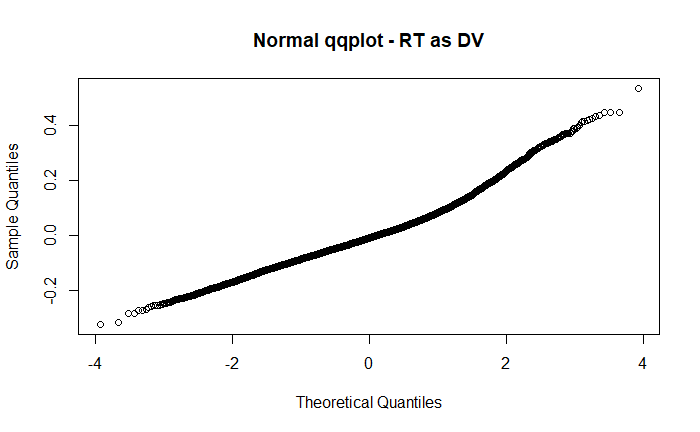

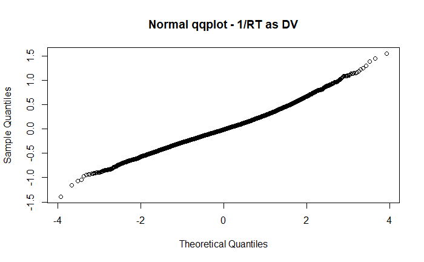

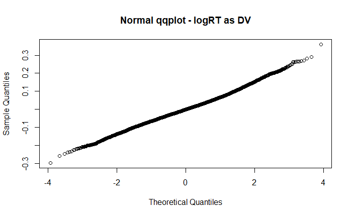

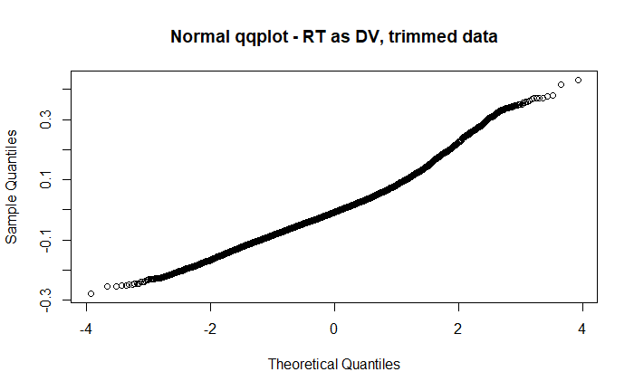

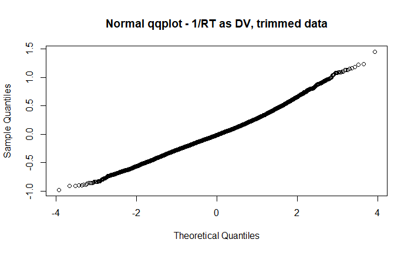

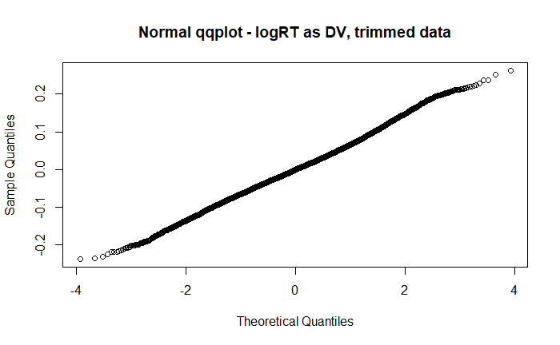

O modelo com RT se comporta pior que os outros dois. Não fica claro, a partir dos gráficos, se a limpeza dos dados altamente influentes melhora ou prejudica o modelo.

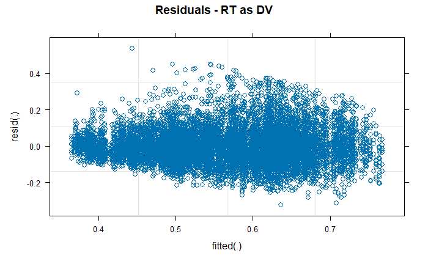

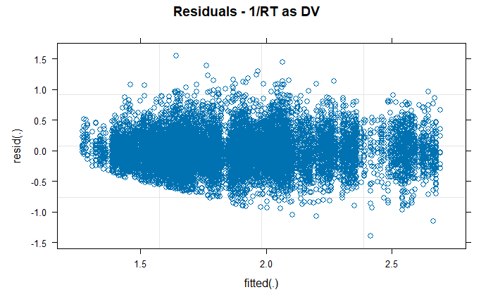

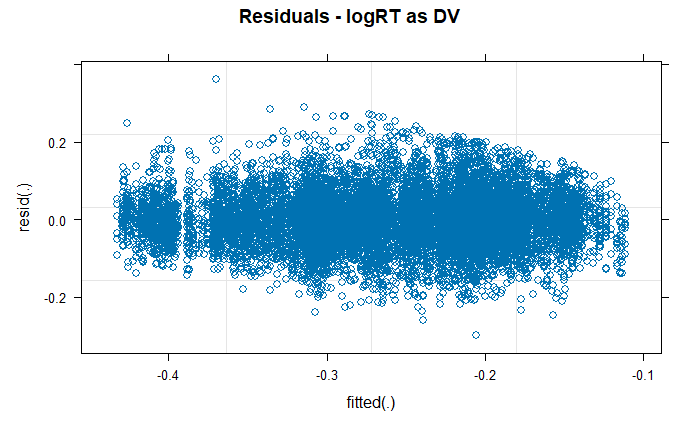

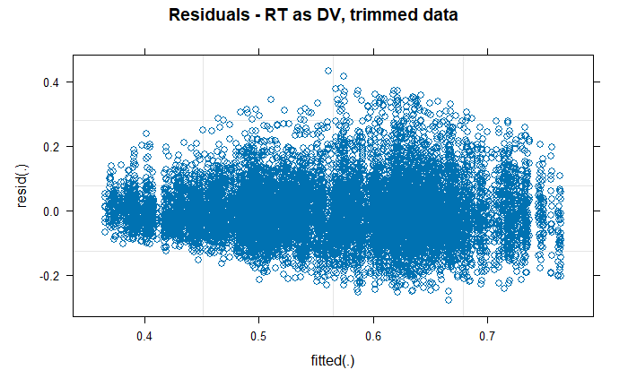

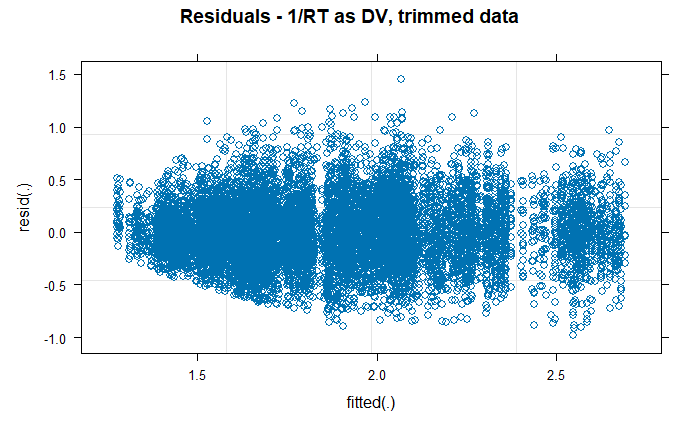

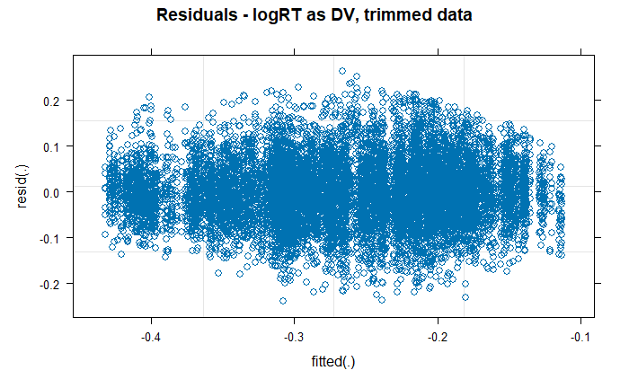

Parece haver uma correlação importante entre os valores ajustados e a dispersão dos resíduos para RT, sendo menos claro para as outras duas transformações.

No geral, RT parece se comportar pior do que 1/RT e logRT. Entre essas duas transformações, o desempenho do modelo parece depender da métrica utilizada. Devido a isso, escolhemos logRT como variável dependente devido à maior interpretabilidade, e para permitir uma comparação dos parâmetros do modelo com aqueles obtidos para o experimento anterior.

# 2. Encontrar máxima estrutura que convirja

Aqui, encontrar a estrutura máxima do modelo que convirja. Há uma série de algoritmos para isso, incluindo a heurística “keep it maximal” de Barr et al. (2013) e variações. Neste experimento, utilizamos o pacote buildmer (Voeten 2022), que automatiza esse processo. Em outro documento, comparamos o desempenho do buildmer com as heurísticas manuais e observamos que os resultados são qualitativamente idênticos.

```r
fplmm <- buildmer(formula = logRT ~ foreperiod*condition*oneBackFP +
                    (1+foreperiod*condition*oneBackFP|ID),
                  data = data2,
                  buildmerControl = list(crit = "LRT",
                                         family = gaussian(link = "identity"),
                                         include = ~ foreperiod * condition * oneBackFP,
                                         calc.anova = TRUE))
```

|  | grouping | term | block | score | Iteration | LRT |
| --- | --- | --- | --- | --- | --- | --- |
| 1 | NA | 1 | NA | NA | 1 | NA |
| 2 | NA | foreperiod | NA | NA | 1 | NA |
| 3 | NA | condition | NA | NA | 1 | NA |
| 4 | NA | foreperiod:condition | NA | NA | 1 | NA |
| 5 | NA | oneBackFP | NA | NA | 1 | NA |
| 6 | NA | foreperiod:oneBackFP | NA | NA | 1 | NA |
| 7 | NA | condition:oneBackFP | NA | NA | 1 | NA |
| 8 | NA | foreperiod:condition:oneBackFP | NA | NA | 1 | NA |
| 9 | ID | 1 | NA ID 1 | -Inf | 1 | NA |
| 11 | ID | condition | NA ID condition | -216.7077 | 1 | 7.674565e-95 |

```r
formula(fplmm)
```

```
logRT ~ 1 + foreperiod + condition + foreperiod:condition + oneBackFP +
    foreperiod:oneBackFP + condition:oneBackFP + foreperiod:condition:oneBackFP +
    (1 + condition | ID)
```

# 3. Compare log-transform to log-link function

```r
fplmm <- mixed(formula = logRT ~ 1 + foreperiod + condition + foreperiod:condition + oneBackFP +
                 foreperiod:oneBackFP + condition:oneBackFP + foreperiod:condition:oneBackFP +
                 (1 + condition | ID),
               data=data2,
               control = lmerControl(optimizer = c("bobyqa"),optCtrl=list(maxfun=2e5),calc.derivs = FALSE),
               progress = TRUE,
               expand_re = FALSE,
               method =  'KR',
               REML=TRUE,
               return = "merMod")
```

```r
anova(fplmm)
```

```
Type III Analysis of Variance Table with Satterthwaite's method
                                Sum Sq  Mean Sq NumDF DenDF F value    Pr(>F)
foreperiod                     0.55670 0.185568     3 11376 41.1866 < 2.2e-16 ***
condition                      0.02296 0.022962     1    37  5.0963 0.0299692 *
oneBackFP                      0.09827 0.032755     3 11376  7.2700 7.214e-05 ***
foreperiod:condition           0.08578 0.028593     3 11376  6.3461 0.0002704 ***
foreperiod:oneBackFP           0.18591 0.020657     9 11380  4.5847 4.598e-06 ***
condition:oneBackFP            0.01540 0.005132     3 11376  1.1390 0.3317181
foreperiod:condition:oneBackFP 0.06091 0.006767     9 11380  1.5020 0.1406866
---
Signif. codes:  0 ‘***’ 0.001 ‘**’ 0.01 ‘*’ 0.05 ‘.’ 0.1 ‘ ’ 1
```

```r
fpglmm <- mixed(formula = RT ~ 1 + foreperiod + condition + foreperiod:condition + oneBackFP +
                 foreperiod:oneBackFP + condition:oneBackFP + foreperiod:condition:oneBackFP +
                 (1 + condition | ID),
               data=data2,
               family = gaussian(link = "log"),
               control = glmerControl(optimizer = c("bobyqa"),optCtrl=list(maxfun=2e5),calc.derivs = FALSE),
               progress = TRUE,
               expand_re = FALSE,
               method =  'PB',
               return = "merMod")
```

```
Contrasts set to contr.sum for the following variables: foreperiod, condition, oneBackFP, ID
```

```r
anova(fpglmm)
```

```
Analysis of Variance Table
                               npar  Sum Sq  Mean Sq F value
foreperiod                        3 0.89166 0.297219 35.0713
condition                         1 0.13465 0.134650 15.8884
oneBackFP                         3 0.19892 0.066308  7.8242
foreperiod:condition              3 0.08248 0.027494  3.2442
foreperiod:oneBackFP              9 0.26976 0.029973  3.5368
condition:oneBackFP               3 0.04312 0.014375  1.6962
foreperiod:condition:oneBackFP    9 0.09434 0.010483  1.2369
```

```r
library(DHARMa)
simulation_lmm <- simulateResiduals(fittedModel = fplmm, n = 1000, plot = F)
```

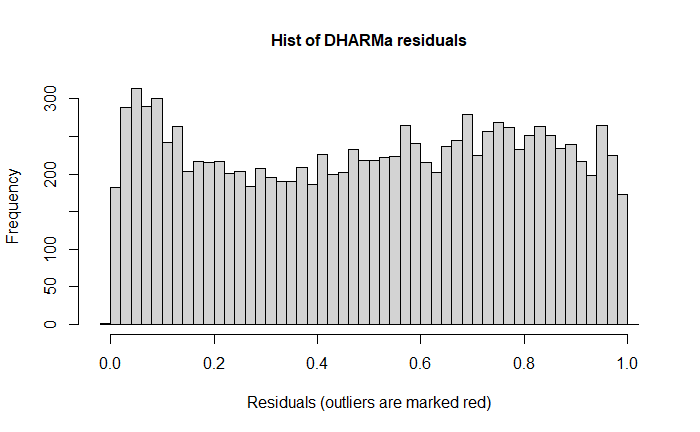

```r
# Histogram
hist(simulation_lmm)
```

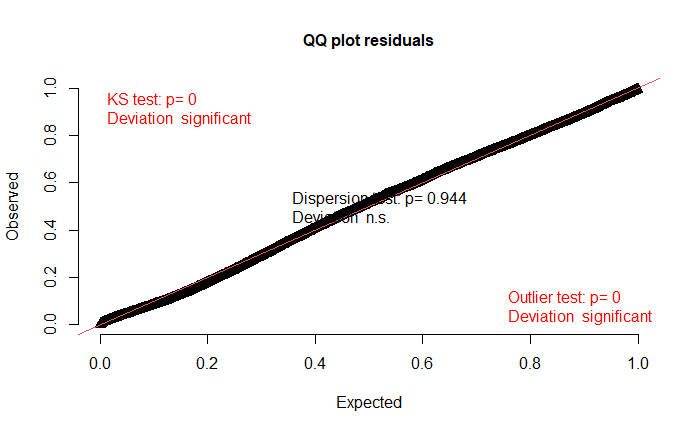

```r
# QQ-plots
plotQQunif(simulation_lmm)
```

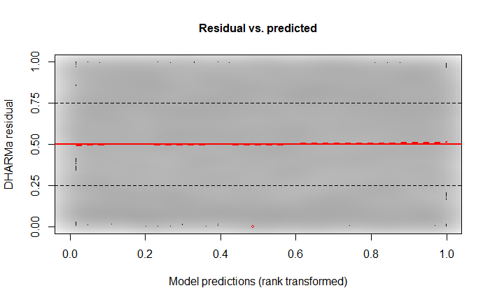

```r
# Residuals vs fitted values
plotResiduals(simulation_lmm)
```

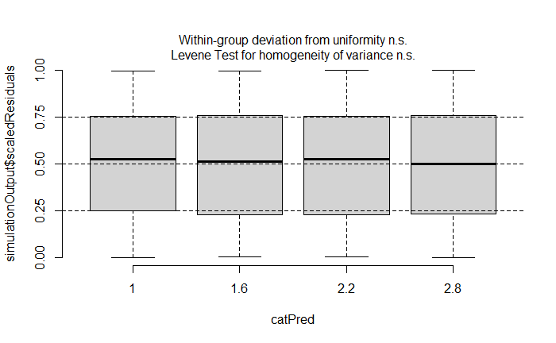

```r
# Against foreperiod
plotResiduals(simulation_lmm, form = data2$foreperiod)
```

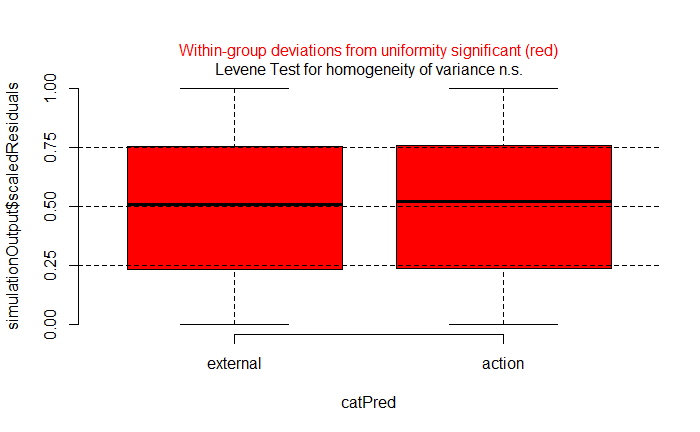

```r
# Against condition
plotResiduals(simulation_lmm, form = data2$condition)
```

```r
simulation_glmm <- simulateResiduals(fittedModel = fpglmm, n = 1000, plot = F)
```

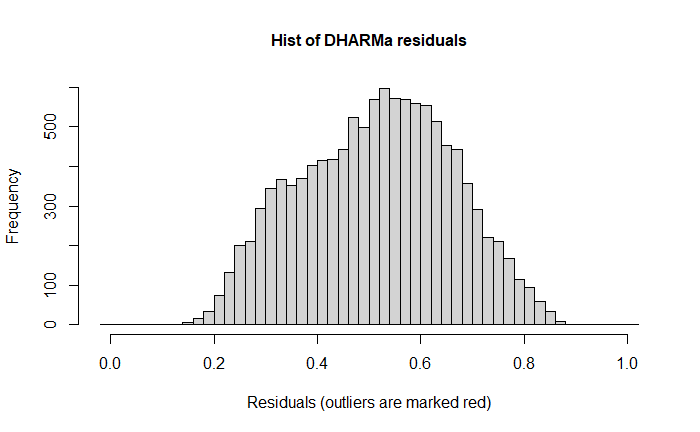

```r
# Histogram
hist(simulation_glmm)
```

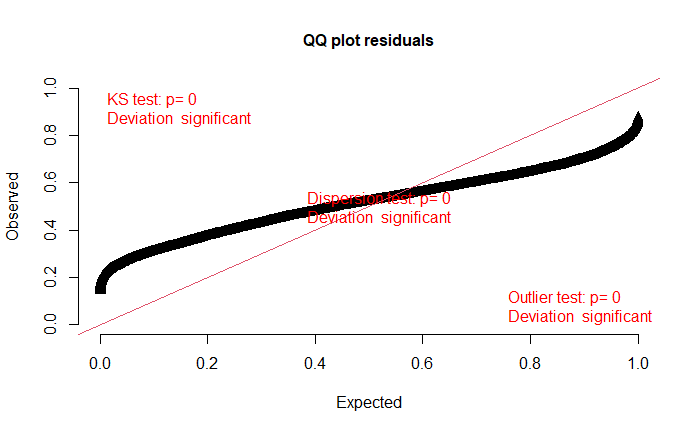

```r
# QQ-plots
plotQQunif(simulation_glmm)
```

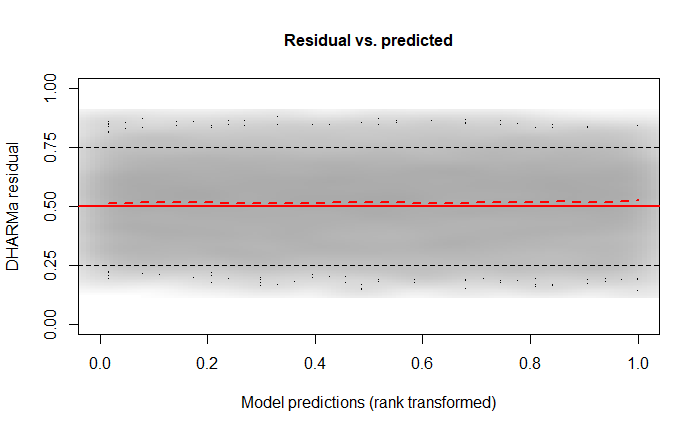

```r
# Residuals vs fitted values
plotResiduals(simulation_glmm)
```

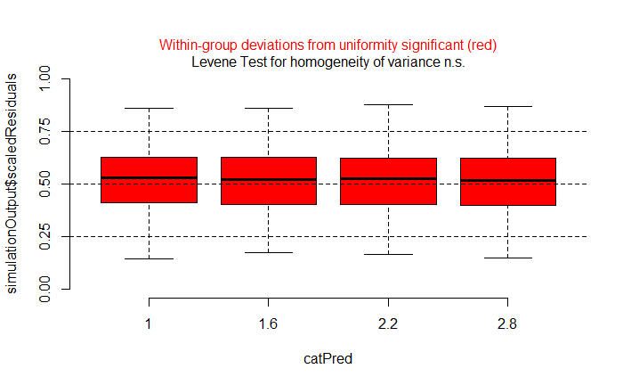

```r
# Against foreperiod
plotResiduals(simulation_glmm, form = data2$foreperiod)
```

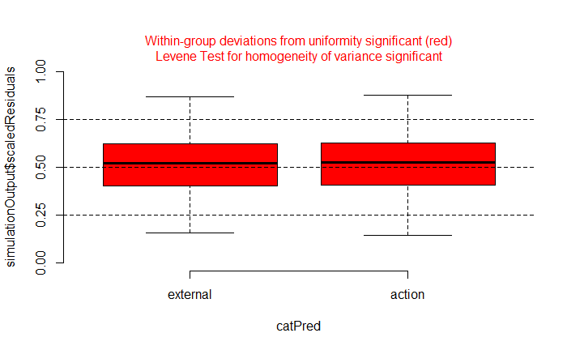

```r
# Against condition
plotResiduals(simulation_glmm, form = data2$condition)
```

# 4. Find maximal converging structure for error analysis

```r
fpaccglmm <- buildmer(error_result ~ foreperiod * condition * oneBackFP +
                         (1+foreperiod*condition*oneBackFP|ID),
                       data=dataAcc,
                       family = binomial(link = "logit"),
                       buildmerControl = buildmerControl(calc.anova = TRUE, ddf = "Satterthwaite",
                                                         include = ~ foreperiod:condition:oneBackFP))
```

[output not shown]

|  | grouping | term | block | score | Iteration | LRT |
| --- | --- | --- | --- | --- | --- | --- |
| 1 | NA | 1 | NA | NA | 1 | NA |
| 2 | NA | foreperiod:condition:oneBackFP | NA | NA | 1 | NA |
| 21 | NA | foreperiod | NA NA foreperiod | 0 | 1 | NA |
| 3 | NA | condition | NA NA condition | 0 | 1 | NA |
| 5 | NA | oneBackFP | NA NA oneBackFP | 0 | 1 | NA |
| 4 | NA | foreperiod:condition | NA NA foreperiod:condition | 0 | 1 | NA |
| 6 | NA | foreperiod:oneBackFP | NA NA foreperiod:oneBackFP | 0 | 1 | NA |
| 7 | NA | condition:oneBackFP | NA NA condition:oneBackFP | 0 | 1 | NA |

```
All terms are significant
```

```r
formula(fpaccglmm)
```

```
error_result ~ 1 + foreperiod:condition:oneBackFP + foreperiod +
    condition + oneBackFP + foreperiod:condition + foreperiod:oneBackFP +
    condition:oneBackFP
```

# References

Barr, Dale J., Roger Levy, Christoph Scheepers, and Harry J. Tily. 2013. “Random Effects Structure for Confirmatory Hypothesis Testing: Keep It Maximal.” *Journal of Memory and Language* 68 (3): 255–78. https://doi.org/10.1016/j.jml.2012.11.001.

Voeten, Cesko C. 2022. *Buildmer: Stepwise Elimination and Term Reordering for Mixed-Effects Regression*. https://CRAN.R-project.org/package=buildmer.